# Untitled

```r
library(dplyr)
# data <- read.csv("../../.././data./01-modified-data./cleaned_data_r1.csv", stringsAsFactors = FALSE)
data <- read.csv("../../../data/01-modified-data/cleaned_data_r1.csv", stringsAsFactors = FALSE)
```

```r
head(data)
```

```
           title score                           term
1   肖申克的救赎   9.7                 希望让人自由。
2       霸王别姬   9.6                     风华绝代。
3       阿甘正传   9.5             一部美国近现代史。
4     泰坦尼克号   9.5            失去的才是永恒的。
5 这个杀手不太冷   9.4 怪蜀黍和小萝莉不得不说的故事。
6       千与千寻   9.4  最好的宫崎骏，最好的久石让。
                                  other                          quote
1          月黑高飞(港)    刺激1995(台)                 希望让人自由。
2 再见，我的妾    Farewell My Concubine                     风华绝代。
3                         福雷斯特·冈普             一部美国近现代史。
4                      铁达尼号(港  台)             失去的才是永恒的。
5            终极追杀令(台)    杀手莱昂 怪蜀黍和小萝莉不得不说的故事。
6        神隐少女(台)    千与千寻的神隐   最好的宫崎骏，最好的久石让。
```

```r
str(data)
```

```
'data.frame':   100 obs. of  5 variables:
 $ title: chr  "肖申克的救赎" "霸王别姬" "阿甘正传" "泰坦尼克号" ...
 $ score: num  9.7 9.6 9.5 9.5 9.4 9.4 9.6 9.4 9.6 9.4 ...
 $ term : chr  "希望让人自由。" "风华绝代。" "一部美国近现代史。" "失去的才是永恒的。 " ...
 $ other: chr  "月黑高飞(港)    刺激1995(台)" "再见，我的妾    Farewell My Concubine" "福雷斯特·冈普" "铁达尼号(港  台)" ...
 $ quote: chr  "希望让人自由。" "风华绝代。" "一部美国近现代史。" "失去的才是永恒的。" ...
```

```r
summary(data$score)
```

```
   Min. 1st Qu.  Median    Mean 3rd Qu.    Max.
  8.700   9.000   9.150   9.153   9.300   9.700
```

```r
length(unique(data$title)) == nrow(data)
```

```
[1] TRUE
```

```r
colSums(is.na(data))
```

```
title score  term other quote
    0     0     0     0     0
```

```r
mean_score <- mean(data$score, na.rm = TRUE)
median_score <- median(data$score, na.rm = TRUE)
sd_score <- sd(data$score, na.rm = TRUE)
var_score <- var(data$score, na.rm = TRUE)
get_mode <- function(v) {
  uniqv <- unique(v)
  uniqv[which.max(tabulate(match(v, uniqv)))]
}
mode_score <- get_mode(data$score)

cat("Mean score:", mean_score, "\n")
```

```
Mean score: 9.153
```

```r
cat("Median score:", median_score, "\n")
```

```
Median score: 9.15
```

```r
cat("Mode score:", mode_score, "\n")
```

```
Mode score: 9.1
```

```r
cat("Standard Deviation of score:", sd_score, "\n")
```

```
Standard Deviation of score: 0.2110364
```

```r
cat("Variance of score:", var_score, "\n")
```

```
Variance of score: 0.04453636
```

```r
term_freq <- table(data$term)
quote_freq <- table(data$quote)

#print(term_freq)
#print(quote_freq)
#too long
```

[figure not shown]

```r
library(ggplot2)

ggplot(data, aes(x=term)) +
  geom_bar() +
  theme(axis.text.x = element_text(angle = 45, hjust = 1)) +
  labs(title="Frequency Distribution of Terms", x="Terms", y="Frequency")
```

[figure not shown]

```r
ggplot(data, aes(x=quote)) +
  geom_bar() +
  theme(axis.text.x = element_text(angle = 45, hjust = 1)) +
  labs(title="Frequency Distribution of Quotes", x="Quotes", y="Frequency")
```

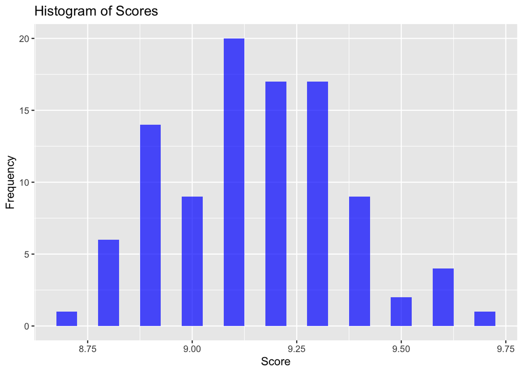

```r
ggplot(data, aes(x=score)) +
  geom_histogram(binwidth=0.05, fill="blue", alpha=0.7) +
  labs(title="Histogram of Scores", x="Score", y="Frequency")
```

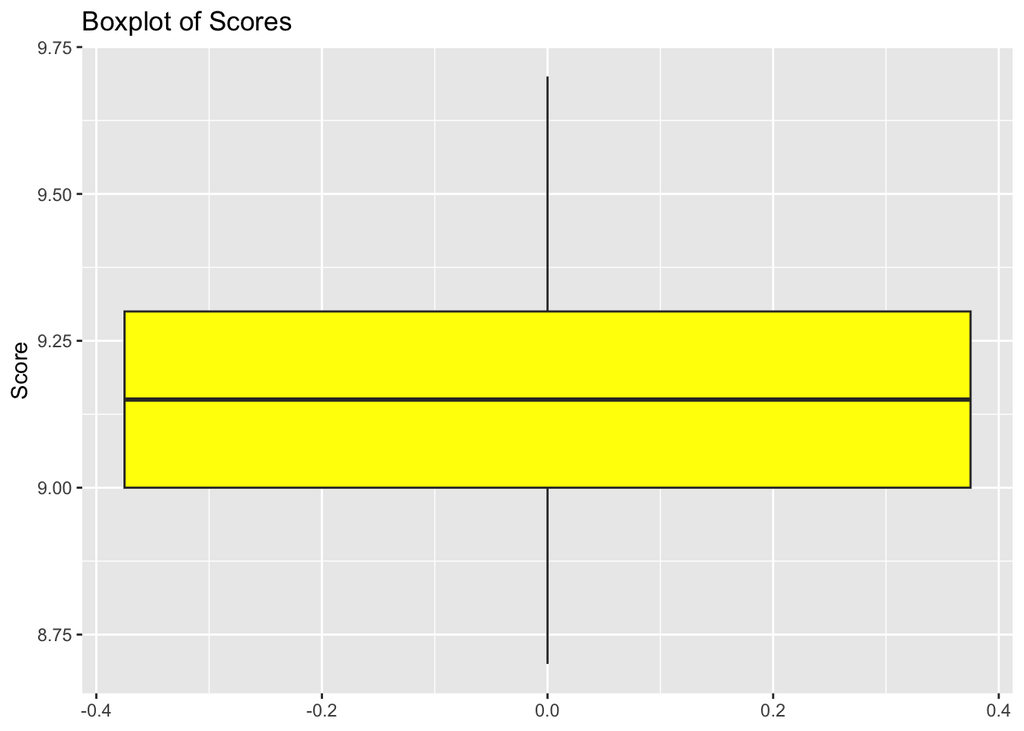

```r
ggplot(data, aes(y=score)) +
  geom_boxplot(fill="yellow", outlier.color="red", outlier.shape=21) +
  labs(title="Boxplot of Scores", y="Score")
```

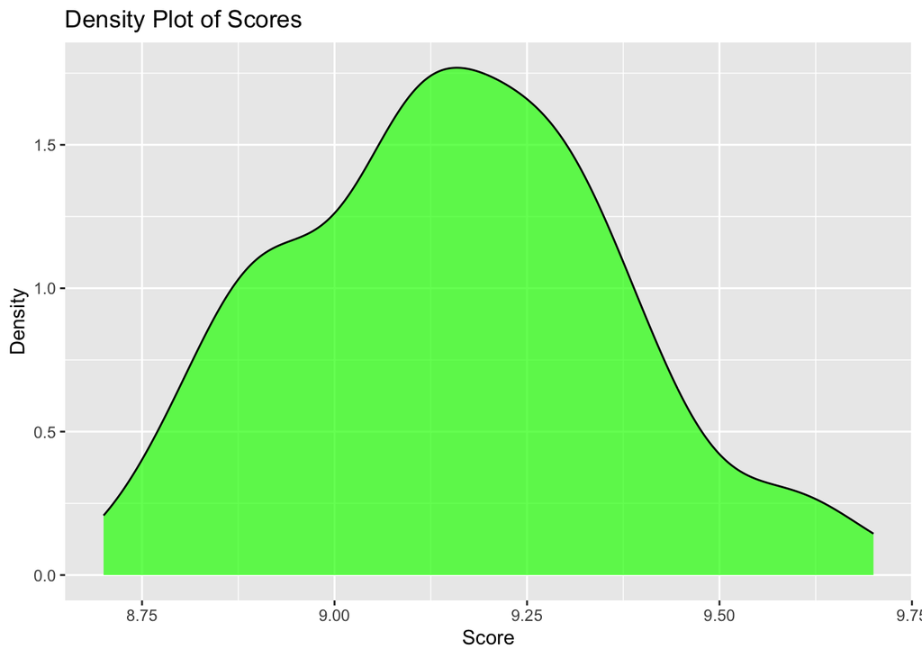

```r
ggplot(data, aes(x=score)) +
  geom_density(fill="green", alpha=0.7) +
  labs(title="Density Plot of Scores", x="Score", y="Density")
```

This dataset is the top 100 ratings on a specialized movie website in China.

1. Audience Preference for High Quality Movies: Since this is the data of the top 100 movie ratings and the scores are mainly concentrated in the range of 9 to 10, it may indicate that the audience prefers high quality movies on this website.

2. Professional rating standard: Considering that the scores of most movies are concentrated in a small range, the rating standard of this movie website may be relatively professional and strict.

3. Possible differences in viewers’ rating habits: Even though all these movies are in the top 100, differences in ratings between them still exist. This may mean that viewers have different rating habits, expectations and preferences.

4. Classics vs. new releases: In the top one hundred, there may be some old classics while some are new releases in recent years. There may be differences in the distribution of ratings between them, which could be an interesting point of hypothesis.

5. Differences in movie genres: Different types of movies (e.g., action, romance, sci-fi, etc.) may have differences in ratings. One hypothesis is that certain types of movies may be more popular or score higher on this site.

6. Influence of directors and actors: Some directors or actors may score their movies higher due to their popularity and reputation in the industry. Audiences may be more inclined to give higher scores to movies with well-known directors or actors.

This dataset is mainly ratings and short reviews, there is no other valuable information, I will try to add these data manually later, here is a list of my assumptions first

```r
data$group <- cut(data$score, breaks = c(0, 9, 9.5, 10), labels = c("<9.0", "9.0-9.5", ">=9.5"), include.lowest = TRUE, right = FALSE)

grouped_data <- data %>% group_by(group) %>%
  summarise(
    count = n(),
    avg_score = mean(score),
    min_score = min(score),
    max_score = max(score)
  )

print(grouped_data)
```

```
# A tibble: 3 × 5
  group   count avg_score min_score max_score
  <fct>   <int>     <dbl>     <dbl>     <dbl>
1 <9.0       21      8.86       8.7       8.9
2 9.0-9.5    72      9.20       9         9.4
3 >=9.5       7      9.59       9.5       9.7
```

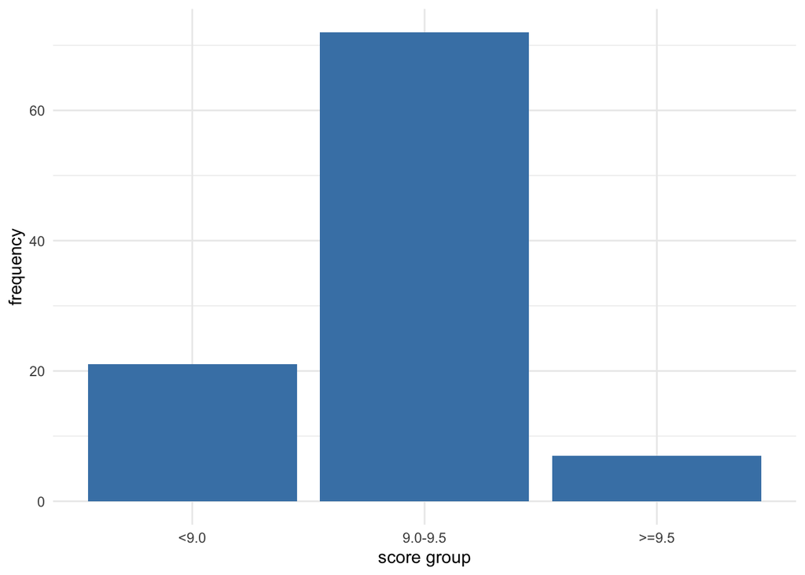

```r
ggplot(grouped_data, aes(x = group, y = count)) +
  geom_bar(stat="identity", fill = "steelblue") +
  labs(x = "score group", y = "frequency") +
  theme_minimal()
```

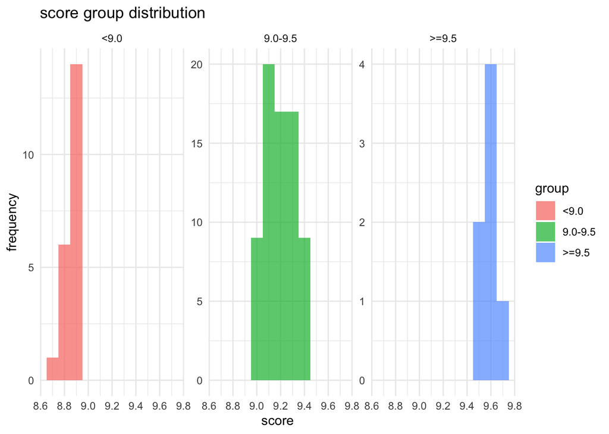

```r
ggplot(data, aes(x = score, fill = group)) +
  geom_histogram(binwidth = 0.1, position="identity", alpha=0.7) +
  labs(title = "score group distribution", x = "score", y = "frequency") +
  theme_minimal() +
  facet_wrap(~group, scales = "free_y")
```

```r
library(jiebaR)
library(tidyverse)
```

```r
jieba_cut <- worker(bylines = F)  # 初始化分词函数

data$words <- lapply(data$term, function(sentence) {
  unlist(segment(sentence, jieba_cut))
})
```

```r
stop_words <- c("我", "你", "他", "她", "它", "我们", "你们", "他们", "的", "和", "在",
                "是", "了", "有", "就", "可以", "都", "不", "一个", "为", "上", "和",
                "也", "中", "到", "说", "要", "以", "这", "对", "与", "及", "很", "但",
                "与其", "之", "等", "或", "如", "那", "而", "被", "人", "之一", "吧", "呢",
                "吗", "会", "更", "还", "让", "做", "因", "所", "其", "没", "最", "自己", "之间",
                "没有", "时", "年", "着", "之后", "应", "地", "得", "过", "大", "只", "等等","的")

data$words <- lapply(data$term, function(sentence) {
  words <- unlist(segment(sentence, jieba_cut))
  words[!words %in% stop_words]
})

word_count <- data %>%
  unnest(words) %>%
  count(words, sort = TRUE) %>%
  filter(!words %in% stop_words)
word_count
```

```
# A tibble: 419 × 2
   words     n
   <chr> <int>
 1 电影      7
 2 不是      5
 3 世界      5
 4 人生      5
 5 永远      5
 6 一部      4
 7 就是      4
 8 才        4
 9 故事      4
10 这样      4
# ℹ 409 more rows
```

[figure not shown]

```r
ggplot(word_count[1:20,], aes(x = reorder(words, n), y = n)) +
  geom_bar(stat = "identity", fill = "steelblue") +
  coord_flip() +
  labs(x = "key word", y = "frequency") +
  theme_minimal()
```

[figure not shown]

```r
library(wordcloud)
library(jiebaR)
library(tm)
jiebar <- worker()

seg_words <- unlist(lapply(data$term, function(x) segment(x, jiebar = jiebar)))

seg_words_clean <- seg_words[!seg_words %in% stop_words]

wordcloud(words = seg_words_clean, min.freq = 2, max.words = 100,
          random.order = FALSE, colors = brewer.pal(8, "Dark2"))
```

[figure not shown]

```r
library(jiebaR)
library(wordcloud)
library(RColorBrewer)

group1 <- data[data$score >= 9.5,]
group2 <- data[data$score < 9.5 & data$score >= 9.0,]
group3 <- data[data$score < 9.0,]


generate_wordcloud <- function(data_group) {
  seg_words <- unlist(lapply(data_group$term, function(x) segment(x, jiebar = jiebar)))
  seg_words_clean <- seg_words[!seg_words %in% stop_words]
  wordcloud(words = seg_words_clean, min.freq = 2, max.words = 100, random.order = FALSE, colors = brewer.pal(8, "Dark2"))
}


generate_wordcloud(group1)
```

[figure not shown]

```r
generate_wordcloud(group2)
```

[figure not shown]

```r
generate_wordcloud(group3)
```

[figure not shown]

```r
extract_keywords <- function(data_group) {
  seg_words <- unlist(lapply(data_group$term, function(x) segment(x, jiebar = jiebar)))
  seg_words_clean <- seg_words[!seg_words %in% stop_words]
  freq_table <- table(seg_words_clean)
  return(freq_table)
}
freq_group1 <- extract_keywords(group1)
freq_group2 <- extract_keywords(group2)
freq_group3 <- extract_keywords(group3)
df_group1 <- as.data.frame(freq_group1) %>% arrange(-Freq) %>% head(20) #
df_group2 <- as.data.frame(freq_group2) %>% arrange(-Freq) %>% head(20)
df_group3 <- as.data.frame(freq_group3) %>% arrange(-Freq) %>% head(20)

plot_keywords <- function(df, title) {
  ggplot(df, aes(x = reorder(seg_words_clean, Freq), y = Freq)) +
    geom_bar(stat = "identity", fill = "steelblue") +
    coord_flip() +
    labs(title = title, x = "Keywords", y = "Frequency") +
    theme_minimal()
}

plot_keywords(df_group1, "Keywords for Group 1 (score > 9.5)")
```

[figure not shown]

```r
plot_keywords(df_group2, "Keywords for Group 2 (9.0 <= score <= 9.5)")
```

[figure not shown]

```r
plot_keywords(df_group3, "Keywords for Group 3 (score < 9.0)")
```

7.There is no identifying outliers.

*ANSWER for 8*

#### Introduction:

The purpose of this report is to provide an overview of the Exploratory Data Analysis (EDA) conducted on the **`cleaned_data_r1.csv`** dataset. The dataset primarily contains terms and their associated scores, offering insights into sentiments or importance. We delved into the data, uncovering patterns, distributions, and relationships that can help in further research or decision-making.

#### 2. Data Distribution:

- **Score Distribution**: Most of the scores lie in the range between 9 and 10. The data indicates a high degree of positivity or favorability in terms.

#### 5. Visual Representation:

- **Histogram**: A histogram showcased the distribution of scores, indicating the concentration of terms in the higher score range.
- **Word Cloud**: A word cloud visualization highlighted the prominence of certain keywords in the dataset, with size indicating frequency.

#### Conclusion:

The EDA on **`cleaned_data_r1.csv`** has unveiled several insights into the nature and themes of the terms. The data leans towards positivity, with particular emphasis on certain key themes. These insights can provide a foundational understanding for further in-depth analysis, modeling, or strategic decision-making based on the dataset’s context.

Note: The above report provides a structured summary based on the EDA activities we’ve conducted thus far. It’s essential to adjust or expand upon these findings if more in-depth analysis or additional insights were gleaned from the data.

*ANSWER for 9*

Tools and Software for Exploratory Data Analysis (EDA) on “cleaned_data_r1.csv”

In the process of handling and analyzing the dataset “cleaned_data_r1.csv,” various tools and software were utilized. Here’s a tailored discussion on those tools and their specific roles:

R:

Given that the operations performed on “cleaned_data_r1.csv” were conducted in R, it stands as the primary language for this EDA.

dplyr: This package was frequently employed for data manipulation tasks, including filtering, grouping, and summarizing the data. Its intuitive syntax made these operations efficient.

tidyr: Whenever the data needed reshaping or restructuring, tidyr provided the necessary functions. This was especially useful in ensuring the dataset adhered to the tidy data principles.

JiebaR:

Given the presence of Chinese text in the dataset, the JiebaR package played a crucial role. It was used for segmenting Chinese text into words, facilitating term frequency analysis and ensuring the word clouds generated were accurate and insightful.

In Conclusion:

The combination of R with its diverse packages and the RStudio environment ensured a comprehensive and insightful EDA on “cleaned_data_r1.csv.” These tools, combined with domain knowledge and analytical techniques, were key in extracting meaningful insights from the data.